# 6: Analysis of longitudinal data

## This weeks self learning

This week I red the provided chapter 8 and 9 from Vehkalahti, Kimmo & Everitt, Brian S. (2019). Additionally, I studied some of the topics from textbooks in my mother lamguage because sometimes I struggled with understanding all the new concepts in English. I deepened the learning by doing the Exercise6.Rmd and now feel more or less prepared for doing the assignment 6.

## Some preparation

I loaded all necessary packages and save some functions in the global environment to avoid issues with identical named functions. Additionally, load the data sets I already prepared in the data wrangling tasks. NB: I had to factorize some variables again.

```r
# load packages and save some relevant functions
library('tidyverse')
select <- dplyr::select
rename <- dplyr::rename
filter <- dplyr::filter
library('MASS')
library('corrplot')
library('gridExtra')
library('factoextra')
library('cluster')
library('tibble')
library('GGally')
library('FactoMineR')
library(plotrix)
library(lme4)

# set global theme for ggplot
theme_set(theme_test()) # set new 'default' theme for any ggplot

# load data
RATSL <- read.csv(file = 'C:/Users/filib/Documents/Studium/Semester 7 (Erasmus)/Introduction to Open Data Science/IODS-project/data/ratsl_data.csv')
BPRSL <- read.csv(file = 'C:/Users/filib/Documents/Studium/Semester 7 (Erasmus)/Introduction to Open Data Science/IODS-project/data/bprsl_data.csv')

# factorise data and remove X column
RATSL <- RATSL %>%
  mutate(ID = as.factor(ID), Group = as.factor(Group)) %>%
  select(-X)
BPRSL <- BPRSL %>%
  mutate(treatment = as.factor(treatment), subject = as.factor(subject)) %>%
  select(-X)
```

## Work on chapter 8 and the Meet and Repeat 1 but with a different dataset: RATSL

### Data exploration and graphical display of longitudinal data

```r
# some general data exploration like in data wrangling task
head(RATSL)
```

```
##   ID Group  WD Weight Time
## 1  1     1 WD1    240    1
## 2  2     1 WD1    225    1
## 3  3     1 WD1    245    1
## 4  4     1 WD1    260    1
## 5  5     1 WD1    255    1
## 6  6     1 WD1    260    1
```

```r
str(RATSL)
```

```
## 'data.frame':    176 obs. of  5 variables:
##  $ ID    : Factor w/ 16 levels "1","2","3","4",..: 1 2 3 4 5 6 7 8 9 10 ...
##  $ Group : Factor w/ 3 levels "1","2","3": 1 1 1 1 1 1 1 1 2 2 ...
##  $ WD    : chr  "WD1" "WD1" "WD1" "WD1" ...
##  $ Weight: int  240 225 245 260 255 260 275 245 410 405 ...
##  $ Time  : int  1 1 1 1 1 1 1 1 1 1 ...
```

```r
summary(RATSL)
```

```
##        ID      Group       WD                Weight           Time
##  1      : 11   1:88   Length:176         Min.   :225.0   Min.   : 1.00
##  2      : 11   2:44   Class :character   1st Qu.:267.0   1st Qu.:15.00
##  3      : 11   3:44   Mode  :character   Median :344.5   Median :36.00
##  4      : 11                             Mean   :384.5   Mean   :33.55
##  5      : 11                             3rd Qu.:511.2   3rd Qu.:50.00
##  6      : 11                             Max.   :628.0   Max.   :64.00
##  (Other):110
```

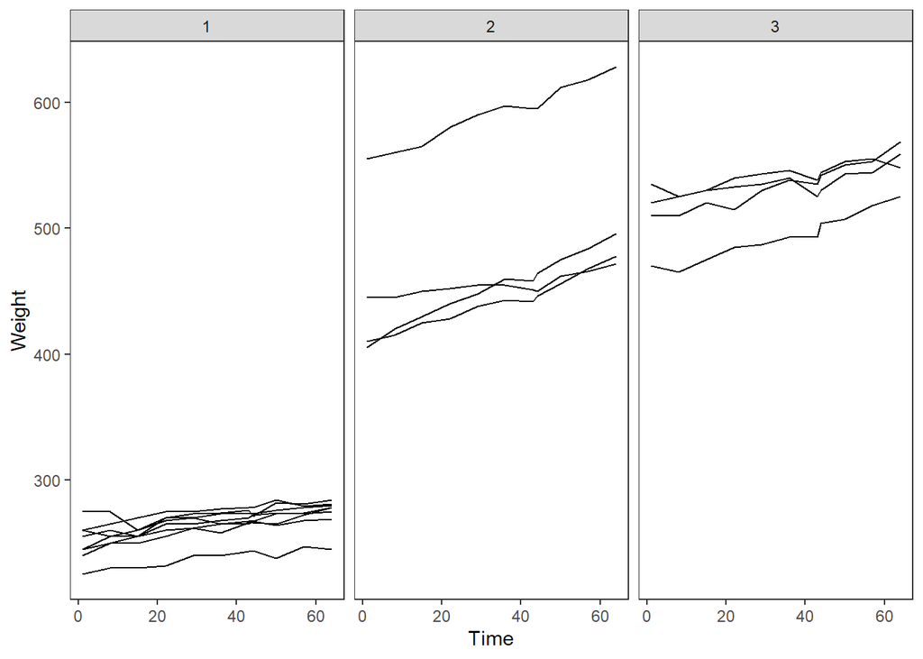

```r
# show graphical overview by plots
RATSL %>% ggplot(aes(x = Time, y = Weight, group = ID)) +
  geom_line() +
  facet_wrap(~Group)
```

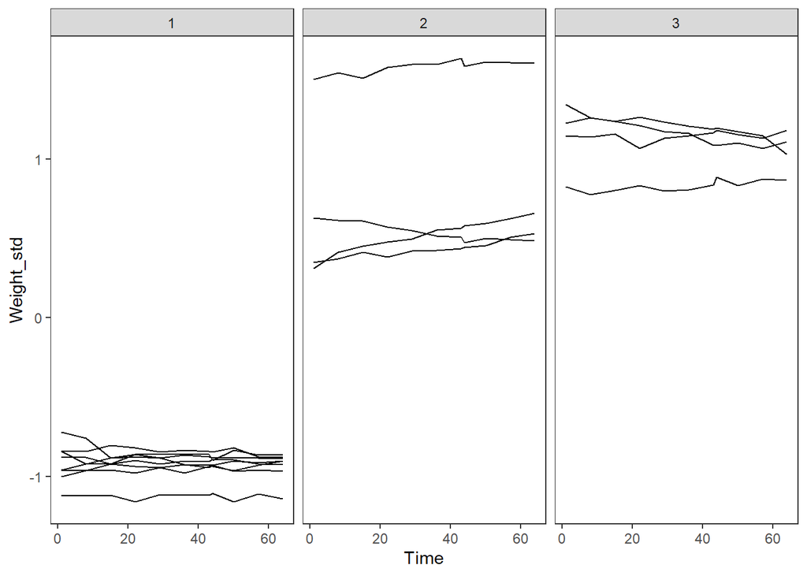

```r
# standardize data
RATSL <- RATSL %>%
  group_by(Time) %>%
  mutate(Weight_std = scale(Weight)) %>% # is the same like scale()
  ungroup()

# show graphical overview for standardized data
RATSL %>% ggplot(aes(x = Time, y = Weight_std, group = ID)) +
  geom_line() +
  facet_wrap(~Group)
```

I plotted a graphical overview on the data - one time with the actual values and one other graph with the standardized data within each ‘time’. The plots with standardized weights show highly different thing: The weight seems to stay more or less constand in Group 1, seems to increase on a high level in Group 2 and seems to decrease in Group 3. In comparison, the unstandardized data shows increasing weights over all Groups.

### Summary statistics

```r
# compute summaries
RATSLS <- RATSL %>%
  group_by(Group, Time) %>%
  summarise(mean = mean(Weight), se = std.error(Weight)) %>%
  ungroup()
```

```r
# plot
# ggplot() +
#  geom_line(data = RATSL, mapping = aes(x = Time, y = Weight, group = ID)) +
#  geom_errorbar(data = RATSLS, mapping = aes(ymin=mean-se, ymax=mean+se, linetype="1"), width=0.3) +
#  facet_wrap(~Group)
```

Somehow there are issues in plotting the errorbars in ggplot - I’m not really able to fix this issue:/

### Search for outliers in the data by applying boxplots

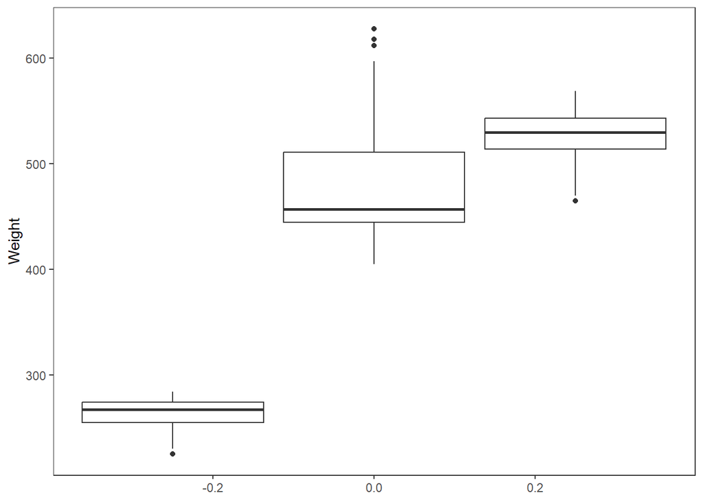

```r
# draw boxplots for each Group
RATSL %>% ggplot(aes(y = Weight, group = Group)) +
  geom_boxplot()
```

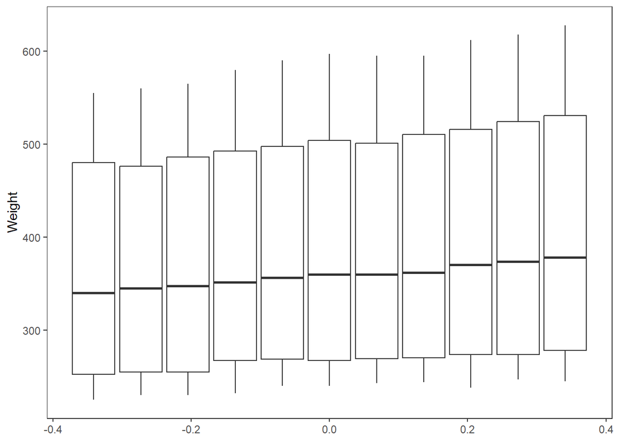

```r
# draw boxplots for each Time
RATSL %>% ggplot(aes(y = Weight, group = Time)) +
  geom_boxplot()
```

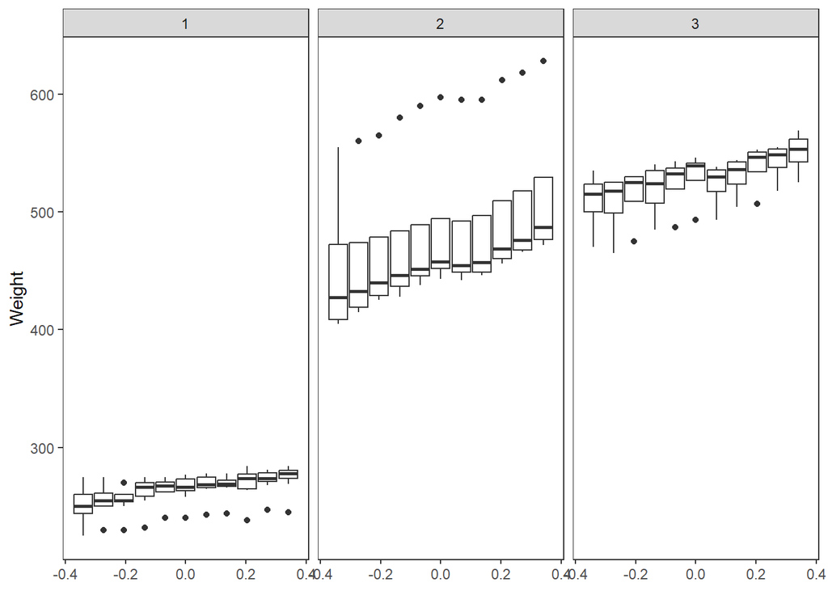

```r
# draw boxplots for each Time and Group
RATSL %>% ggplot(aes(y = Weight, group = Time)) +
  geom_boxplot() +
  facet_wrap(~Group)
```

It has been hard for me to search for outliers - especially, because from my understanding its not really justified to simply exclude outliers without having a sufficient explanation/reason to do this. If the data is not good enough, statistics shouldn’t be used to make the data prettier. However, in the first plots are outliers visible from the points in each group. In plot two do not appear any outlier and in plot 3 are again outliers visible. Only the last plots provides an idea, that maybe measurements for some individuals (ID) seem to be baised by any errors and possibly they could be excluded. Nevertheless, I wont do this here due to a lack of information about possible errors and thus not enough justification for removing data.

### T-test and Anova

```r
# t-test
# t.test(mean ~ Group, data = RATSLS)

# fit lm
fit <- lm(Weight ~ Group + Time, data = RATSL)
summary(fit)
```

```
##
## Call:
## lm(formula = Weight ~ Group + Time, data = RATSL)
##
## Residuals:
##     Min      1Q  Median      3Q     Max
## -60.643 -24.017   0.697  10.837 125.459
##
## Coefficients:
##             Estimate Std. Error t value Pr(>|t|)
## (Intercept) 244.0689     5.7725  42.281  < 2e-16 ***
## Group2      220.9886     6.3402  34.855  < 2e-16 ***
## Group3      262.0795     6.3402  41.336  < 2e-16 ***
## Time          0.5857     0.1331   4.402 1.88e-05 ***
## ---
## Signif. codes:  0 '***' 0.001 '**' 0.01 '*' 0.05 '.' 0.1 ' ' 1
##
## Residual standard error: 34.34 on 172 degrees of freedom
## Multiple R-squared:  0.9283, Adjusted R-squared:  0.9271
## F-statistic: 742.6 on 3 and 172 DF,  p-value: < 2.2e-16
```

```r
# compute table of variance
anova(fit)
```

```
## Analysis of Variance Table
##
## Response: Weight
##            Df  Sum Sq Mean Sq  F value    Pr(>F)
## Group       2 2604050 1302025 1104.197 < 2.2e-16 ***
## Time        1   22847   22847   19.375  1.88e-05 ***
## Residuals 172  202816    1179
## ---
## Signif. codes:  0 '***' 0.001 '**' 0.01 '*' 0.05 '.' 0.1 ' ' 1
```

Firstly, it seems to be not possible to perform a t-test on the data because there are more than 2 groups. Thus, I directly moved forward applying the lm and ANOVA. The linear model showed that both treatments in group 2 and 3 had a significant positive influence on the weight (p-value much below 0.05). Furthermore, the Time had a significant positive impact too.

## Work on chapter 9 and the Meet and Repeat 2 but with a different dataset: BPRS

### plots

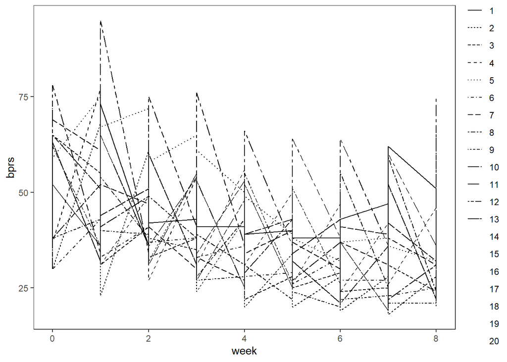

```r
# plot ignoring the longitudinal structure
ggplot(BPRSL, aes(x = week, y = bprs, linetype = subject)) +
  geom_line()
```

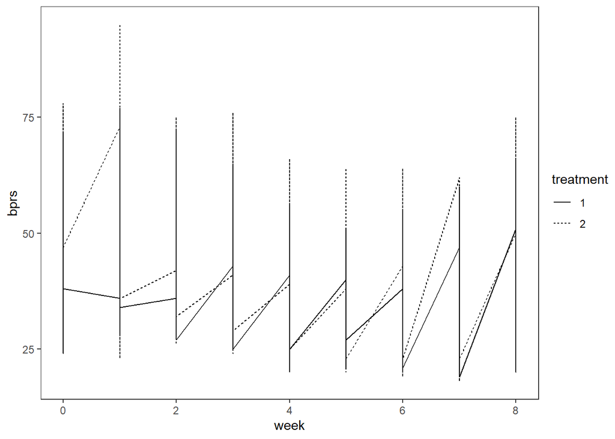

```r
# another plot ignoring the longitudinal structure
ggplot(BPRSL, aes(x = week, y = bprs, linetype = treatment)) +
  geom_line()
```

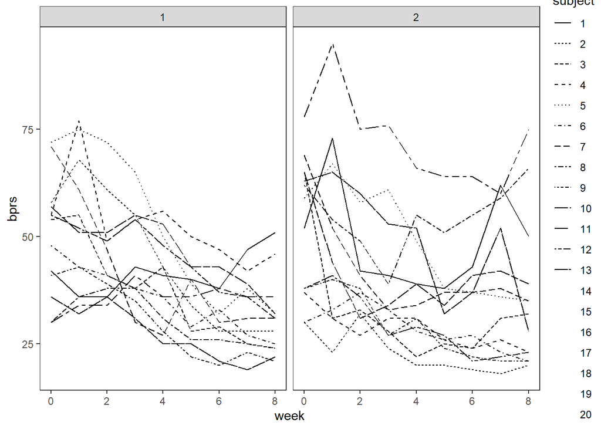

```r
# plot
ggplot(BPRSL, aes(x = week, y = bprs, linetype = subject)) +
  geom_line() +
  facet_wrap(~treatment)
```

I built some line plots with the first trying to ignore the longitudinal structure - this not really is useful. Afterwards, I splitted the data by treatment and some good plots appear.

### Linear model

```r
# fit linear model ignoring the longitudinal structure
BPRSL_reg <- lm(formula = bprs ~ week + treatment, data = BPRSL)
summary(BPRSL_reg) # print model summary
```

```
##
## Call:
## lm(formula = bprs ~ week + treatment, data = BPRSL)
##
## Residuals:
##     Min      1Q  Median      3Q     Max
## -22.454  -8.965  -3.196   7.002  50.244
##
## Coefficients:
##             Estimate Std. Error t value Pr(>|t|)
## (Intercept)  46.4539     1.3670  33.982   <2e-16 ***
## week         -2.2704     0.2524  -8.995   <2e-16 ***
## treatment2    0.5722     1.3034   0.439    0.661
## ---
## Signif. codes:  0 '***' 0.001 '**' 0.01 '*' 0.05 '.' 0.1 ' ' 1
##
## Residual standard error: 12.37 on 357 degrees of freedom
## Multiple R-squared:  0.1851, Adjusted R-squared:  0.1806
## F-statistic: 40.55 on 2 and 357 DF,  p-value: < 2.2e-16
```

The linear regression analysis ignoring the longitudinal data structure shows that treatment 2 dependent on the variable week does not differ significantly from treatment 1 - because of a p-value of 0.661. In comparison to this, the variable week seems to have a negative impact on bprs value that is highly significant.

### Random Intercept model and random Inetercept and Random Slope Model

```r
# fit random intercept model
BPRSL_ref <- lmer(bprs ~ week + treatment + (1 | subject), data = BPRSL, REML = FALSE)
summary(BPRSL_ref) # print summary
```

```
## Linear mixed model fit by maximum likelihood  ['lmerMod']
## Formula: bprs ~ week + treatment + (1 | subject)
##    Data: BPRSL
##
##      AIC      BIC   logLik deviance df.resid
##   2748.7   2768.1  -1369.4   2738.7      355
##
## Scaled residuals:
##     Min      1Q  Median      3Q     Max
## -3.0481 -0.6749 -0.1361  0.4813  3.4855
##
## Random effects:
##  Groups   Name        Variance Std.Dev.
##  subject  (Intercept)  47.41    6.885
##  Residual             104.21   10.208
## Number of obs: 360, groups:  subject, 20
##
## Fixed effects:
##             Estimate Std. Error t value
## (Intercept)  46.4539     1.9090  24.334
## week         -2.2704     0.2084 -10.896
## treatment2    0.5722     1.0761   0.532
##
## Correlation of Fixed Effects:
##            (Intr) week
## week       -0.437
## treatment2 -0.282  0.000
```

```r
# fit random intercept and slope model
BPRSL_ref1 <- lmer(bprs ~ week + treatment + (week | subject), data = BPRSL, REML = FALSE)

# perform an ANOVA test on the two models
anova(BPRSL_ref1, BPRSL_ref)
```

```
## Data: BPRSL
## Models:
## BPRSL_ref: bprs ~ week + treatment + (1 | subject)
## BPRSL_ref1: bprs ~ week + treatment + (week | subject)
##            npar    AIC    BIC  logLik deviance  Chisq Df Pr(>Chisq)
## BPRSL_ref     5 2748.7 2768.1 -1369.4   2738.7
## BPRSL_ref1    7 2745.4 2772.6 -1365.7   2731.4 7.2721  2    0.02636 *
## ---
## Signif. codes:  0 '***' 0.001 '**' 0.01 '*' 0.05 '.' 0.1 ' ' 1
```

### Random Intercept and Random Slope Model with interaction

```r
# fit random intercept and slope model with added interaction
BPRSL_ref2 <- lmer(bprs ~ week + treatment + week * treatment + (week | subject), data = BPRSL, REML = FALSE)
summary(BPRSL_ref2) # print summary
```

```
## Linear mixed model fit by maximum likelihood  ['lmerMod']
## Formula: bprs ~ week + treatment + week * treatment + (week | subject)
##    Data: BPRSL
##
##      AIC      BIC   logLik deviance df.resid
##   2744.3   2775.4  -1364.1   2728.3      352
##
## Scaled residuals:
##     Min      1Q  Median      3Q     Max
## -3.0512 -0.6271 -0.0768  0.5288  3.9260
##
## Random effects:
##  Groups   Name        Variance Std.Dev. Corr
##  subject  (Intercept) 64.9964  8.0620
##           week         0.9687  0.9842   -0.51
##  Residual             96.4707  9.8220
## Number of obs: 360, groups:  subject, 20
##
## Fixed effects:
##                 Estimate Std. Error t value
## (Intercept)      47.8856     2.2521  21.262
## week             -2.6283     0.3589  -7.323
## treatment2       -2.2911     1.9090  -1.200
## week:treatment2   0.7158     0.4010   1.785
##
## Correlation of Fixed Effects:
##             (Intr) week   trtmn2
## week        -0.650
## treatment2  -0.424  0.469
## wek:trtmnt2  0.356 -0.559 -0.840
```

```r
anova(BPRSL_ref2, BPRSL_ref1)
```

```
## Data: BPRSL
## Models:
## BPRSL_ref1: bprs ~ week + treatment + (week | subject)
## BPRSL_ref2: bprs ~ week + treatment + week * treatment + (week | subject)
##            npar    AIC    BIC  logLik deviance  Chisq Df Pr(>Chisq)
## BPRSL_ref1    7 2745.4 2772.6 -1365.7   2731.4
## BPRSL_ref2    8 2744.3 2775.4 -1364.1   2728.3 3.1712  1    0.07495 .
## ---
## Signif. codes:  0 '***' 0.001 '**' 0.01 '*' 0.05 '.' 0.1 ' ' 1
```

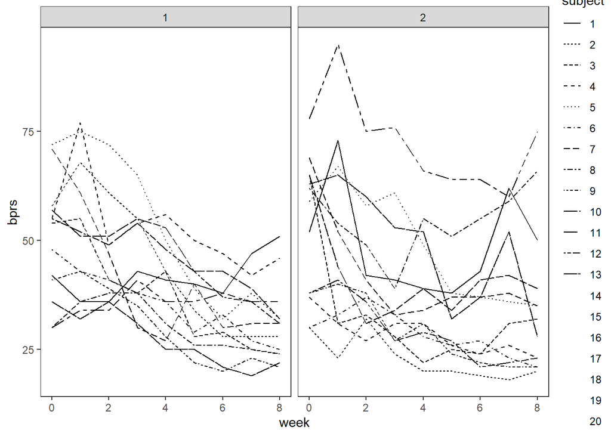

```r
# plot observed values
ggplot(BPRSL, aes(x = week, y = bprs, linetype = subject)) +
  geom_line() +
  facet_wrap(~treatment)
```

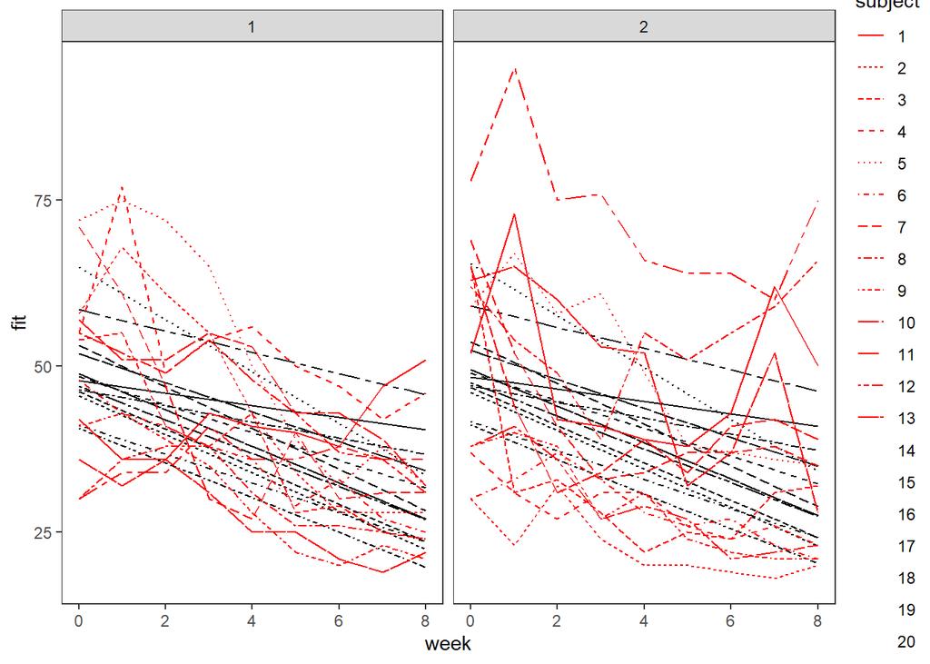

```r
# add fitted values from best model
Fitted <- fitted(BPRSL_ref1)
BPRSL <- BPRSL %>% mutate(fit = Fitted)

# plot observed and fitted values
ggplot(BPRSL, aes(x = week, y = fit, linetype = subject)) +
  geom_line() +
  facet_wrap(~treatment) +
  geom_line(aes(x = week, y = bprs, linetype = subject), color = 'red')
```